# Impact of HCV NAT+ Consent on Liver Transplantation Waitlist Outcomes

BMIN503/EPID600 Final Project

Author

Puru Rattan, MD

## 1 Overview

This is an exploratory project that was initiated to explore the effects of patients being able to consent to receive a hepatitis C virus (HCV) infected organ among end-stage liver disease (ESLD) patients on the United Network for Organ Sharing (UNOS) liver transplant waitlist. The focused goals of the project were to determine trends in consenting for HCV nucleic acid test positive (NAT+) organs and to determine how this has impacted waitlist outcomes.

The full project can be found at https://github.com/pururattan/BMIN503_Final_Project

## 2 Introduction

There is a shortage in the supply of donor livers in the United States for all those on the waiting list for a liver transplant to definitively treat their end-stage liver disease (ESLD). The longer time an individual spends on the waiting list, the higher their probability of dying from liver disease. While true with other organs as well, this mortality is especially stark in ESLD as there are no artificial replacements for the liver, unlike hemodialysis for the kidneys or left ventricular assist devices for the heart. ESLD is the culmination of chronic liver disease (CLD), the burden of which is immense in the United States and is expected to rise in the coming years due to alcohol use and metabolic dysfunction, worsening this supply-demand mismatch.

As such, there have been several concerted efforts to expand the donor pool for liver transplantation. One such effort involves the use of livers from deceased donors with hepatitis C virus (HCV) infection. There is an increased availability of such organs due to deaths from the opioid epidemic, whilst the advent of direct-acting antiviral (DAA) agents has made curing HCV after transplant simple and effective.

Since late 2015, there has been a United Network for Organ Sharing (UNOS) policy to guide individual transplant centers to consent patients on their waiting list to receive an organ from an HCV nucleic acid test positive (NAT+) donor. Additionally in 2020, the CDC and the US Public Health Service (PHS) stipulated that the “increased risk donor” designation be removed from this consent process to reduce cognitive bias and improve decision making. Although this consent process has been adopted nationwide, there is a dearth of data on the trends of consenting and the impact on patients’ waitlist outcomes if they consent to receive an HCV NAT+ liver.

## 3 Methods

We designed a retrospective cohort study using the UNOS Liver database, which contains records of all patients listed for liver transplant in the US. Our analytic cohort was formed by identifying all adult (age >= 18) patients with their initial single-organ liver transplant listing occurring between January 1, 2016 (first full year of HCV NAT+ consent) and September 30, 2023 (upper limit of data). Apart from excluding those below 18 years of age and with multiple organ listings, the patients being listed for hepatocellular carcinoma (liver cancer) related transplant were also excluded.

### 3.1 R Packages

```r
library(tidyverse)
library(hms)
library(tidymodels)
tidymodels_prefer()
```

### 3.2 Data Cleaning

The UNOS database files are not publicly available but were made available to me through my mentorship and research team. Specifically, the following data files were used:

1. `LIVER_DATA` - The main data file consisting of 1 line per unique waitlist registration and all associated information as it currently stands or as it was at time of waitlist removal
2. `LIVER_WLHISTORY_DATA` - A table capturing all the changes made to each waitlist registration, including creation, modification, and deletion. This table records whether the waitlist registration agreed to the HCV NAT+ consent.
3. `UNOS_FLATFILE_FORMATS` - An extracted lookup table from a large UNOS Excel Workbook detailing all codes and their lookups used by UNOS

All these files were current through 09/30/2023. Apart (3), all files are in .dta format as the files were originally requested for analyses with STATA.

```r
liver_data <-
  haven::read_dta(paste0(data_dir,"/Data/LIVER_DATA.DTA")) |>
  rename_with(tolower)

wl_hx <-
haven::read_dta(paste0(data_dir,"/Data/LIVER_WLHISTORY_DATA.DTA")) |>
  rename_with(tolower)

flatfile <-
  read_csv(paste0(data_dir,"/Data/unos_flatfile_formats.csv"),
           col_types = cols(`SASAnalysis Format` = readr::col_factor(),
                            `Data Type` = readr::col_factor())) |>
  rename_with(tolower) |>
  rename_with(~str_replace_all(.x," ","_"))
```

#### 3.2.1 `LIVER_DATA`

```r
#Summary of liver_data table

liver_data |>
  summarize(total_rows = max(row_number()),
            non_null_ids = n_distinct(wl_id_code,na.rm = T),
            cnt_null_ids = sum(is.na(wl_id_code)),
            min_initdt = min(init_date,na.rm = T),
            max_initdt = max(init_date,na.rm = T),
            cnt_null_initdt = sum(is.na(init_date)))
```

```
# A tibble: 1 × 6
  total_rows non_null_ids cnt_null_ids min_initdt max_initdt cnt_null_initdt
       <int>        <int>        <int> <date>     <date>               <int>
1     357269       355577         1692 1985-12-11 2023-09-30            1167
```

```r
liv_data_clean <-
liver_data |>
  mutate(
    sex = factor(gender,
                 levels = c("F", "M"),
                 ordered = T),
    race_eth = factor(
      case_match(
        ethcat,
        1 ~ "White",
        2 ~ "Black",
        4 ~ "Hispanic",
        5 ~ "Asian",
        c(6, 7, 9, 998) ~ "Other",
        .default = NA_character_),
      levels = c("White", "Black", "Hispanic", "Asian", "Other"))) |>
  drop_na(wl_id_code) |> #1692 NULLs, missing most other data or reg < 1988
  select(-"gender") |>
  relocate(wl_id_code) #moves field to front

liv_data_clean |>
    summarize(non_null_ids = n_distinct(wl_id_code,na.rm = T),
              cnt_null_ids = sum(is.na(wl_id_code)),
              min_initdt = min(init_date,na.rm = T),
              max_initdt = max(init_date,na.rm = T),
              cnt_null_initdt = sum(is.na(init_date)))
```

```
# A tibble: 1 × 5
  non_null_ids cnt_null_ids min_initdt max_initdt cnt_null_initdt
         <int>        <int> <date>     <date>               <int>
1       355577            0 1988-01-03 2023-09-30               0
```

```r
liv_data_clean |>
  select(wl_id_code, sex, race_eth) |>
  summary()
```

```
   wl_id_code      sex            race_eth
 Min.   :      6   F:137378   White   :252064
 1st Qu.: 441002   M:218199   Black   : 30642
 Median : 883434              Hispanic: 52914
 Mean   : 882765              Asian   : 15013
 3rd Qu.:1323799              Other   :  4944
 Max.   :1769822
```

```r
rm(liver_data)
```

```r
#Assign Diagnosis Categories based on validated algorithms

liv_data_clean <-
liv_data_clean |>
  mutate(
    diabetes = case_match(diab, 1 ~ F, c(2, 3, 4, 5) ~ T,
                          .default = NA),
    ascites_cat = factor(
      case_when(init_ascites == 4 ~ NA_real_,
                .default = init_ascites),
      labels = c("Absent","Slight","Moderate")),
    new_weight = case_when(
      init_wgt_kg < 20 | init_wgt_kg >= 200 ~ NA_real_,
      ascites_cat == "Absent" |
        is.na(ascites_cat) ~ init_wgt_kg, #Weight adjusted for ascites
      ascites_cat == "Slight" ~ 0.95 * init_wgt_kg,
      ascites_cat == "Moderate" ~ 0.90 * init_wgt_kg,
      .default = NA_real_),
    new_height = case_when(hgt_cm_tcr < 120 ~ NA_real_,
                           .default = hgt_cm_tcr/100),
    new_bmi = new_weight / (new_height ^ 2),
    new_obesity = case_when(race_eth == "Asian" &
                              new_bmi >= 27.5 ~ T,
                            new_bmi >= 30 ~ T,
                            .default = F),
    new_dx = factor(
      case_when(
        dgn_tcr %in% c(4208, 4213, 4400, 4401) &
          dgn2_tcr %in% c(4215, 4217, 4218, 4219) &
          (diabetes == T | new_obesity == T) ~ "MetALD",
        dgn_tcr == 4214 &
          dgn2_tcr %in% c(4215, 4217, 4218, 4219) ~ "MetALD",
        dgn_tcr %in% c(4215, 4217, 4218, 4219) &
          (dgn2_tcr == 4214 | diabetes == T | new_obesity == T) ~ "MetALD",
        dgn_tcr %in% c(4208, 4213) &
          (dgn2_tcr == 4214 | diabetes == T | new_obesity == T) ~ "MASLD",
        dgn_tcr %in% c(4400, 4401) &
          dgn2_tcr == 4214 ~ "MASLD",
        dgn_tcr %in% c(4400, 4401) &
          dgn2_tcr %in% c(4208, 4213) &
          (diabetes == T | new_obesity == T) ~ "MASLD",
        dgn_tcr == 4214 ~ "MASLD",
        dgn_tcr %in% c(4215, 4217, 4218, 4219) ~ "ALD",
        dgn_tcr %in% c(4400, 4401) &
          dgn2_tcr %in% c(4215, 4217, 4218, 4219) ~ "ALD",
        dgn_tcr %in% c(4104, 4106, 4204, 4206, 4216, 4593) ~ "HCV",
        dgn_tcr %in% c(4400, 4401) &
          dgn2_tcr %in% c(4104, 4106, 4204, 4206, 4216, 4593) ~ "HCV",
        dgn_tcr %in% c(4212, 4220, 4240, 4241, 4242, 4245) ~ "Autoimmune",
        dgn_tcr %in% c(4400, 4401) &
          dgn2_tcr %in% c(4212, 4220, 4240, 4241, 4242, 4245) ~ "Autoimmune",
        dgn_tcr %in% c(4102, 4107, 4202, 4207, 4592) ~ "HBV",
        dgn_tcr %in% c(4400, 4401) &
          dgn2_tcr %in% c(4102, 4107, 4202, 4207, 4592) ~ "HBV",
        .default = "Other"),
      levels = c("HCV", "Autoimmune", "MASLD", "ALD", "MetALD", "HBV" , "Other")
    ))

liv_data_clean |>
  select(wl_id_code, diabetes, ascites_cat, new_weight, new_height, new_bmi, new_obesity, new_dx) |>
  summary()
```

```
   wl_id_code       diabetes         ascites_cat       new_weight
 Min.   :      6   Mode :logical   Absent  : 74874   Min.   : 18.00
 1st Qu.: 441002   FALSE:247932    Slight  :125249   1st Qu.: 65.70
 Median : 883434   TRUE :76692     Moderate: 60947   Median : 77.90
 Mean   : 882765   NA's :30953     NA's    : 94507   Mean   : 79.36
 3rd Qu.:1323799                                     3rd Qu.: 91.35
 Max.   :1769822                                     Max.   :199.58
                                                     NA's   :21148
   new_height       new_bmi       new_obesity            new_dx
 Min.   :1.200   Min.   : 6.816   Mode :logical   HCV       : 95435
 1st Qu.:1.630   1st Qu.:23.034   FALSE:263746    Autoimmune: 34590
 Median :1.702   Median :26.422   TRUE :91831     MASLD     : 41331
 Mean   :1.709   Mean   :27.125                   ALD       : 41568
 3rd Qu.:1.780   3rd Qu.:30.516                   MetALD    : 26216
 Max.   :2.250   Max.   :84.388                   HBV       : 10414
 NA's   :27005   NA's   :27382                    Other     :106023
```

```r
#Assign Other Categories based on validated algorithms

liv_data_clean <-
  liv_data_clean |>
  mutate(
    region_us = factor( #REGION
      case_match(
        region,
        c(1, 2, 9) ~ "Northeast",
        c(3, 4, 11) ~ "Southeast",
        c(7, 8, 10) ~ "Midwest",
        c(5, 6) ~ "West"
        ),
      levels = c("Northeast", "Southeast", "Midwest", "West")
      ),
    insurance = factor( #INSURANCE / PAYOR
      case_match(
        pri_payment_tcr,
        c(1,8) ~ "Private",
        c(3,4,13) ~ "Medicare",
        c(2) ~ "Medicaid",
        .default = "Other"
        )
      ),
    ins_public = factor( #PUBLIC INSURANCE
      case_match(
        pri_payment_tcr,
        c(1,8:12) ~ "Not Public",
        c(2:7,13,14) ~ "Public",
        .default = "Unknown"
        )
      ),
    education_tcr = factor( #EDUCATION
      case_match(
        education,
        c(1) ~ "None",
        c(2,3) ~ "Grade/High School",
        c(4,5) ~ "College",
        c(6) ~ "Post-Graduate",
        .default = NA_character_
        )
      ),
    he_cat = factor( #HEPATIC ENCEPHALOPATHY
      case_when(
        init_enceph == 4 ~ NA_real_,
        .default = init_enceph
        ),
      labels = c("None","Grade 1-2","Grade 3-4")
      ),
    dialysis = factor( #DIALYSIS
      case_when(init_dialysis_prior_week == "Y" ~ T,
                init_dialysis_prior_week == "N" ~ F,
                .default = NA)
      ),
    meld_cat = factor( #MELD Score Categories
      case_when(
        init_meld_peld_lab_score < 15 ~ "<15",
        init_meld_peld_lab_score <=25 ~ "15-25",
        init_meld_peld_lab_score >25 ~ ">25",
        .default = NA_character_
        ),
      levels = c("<15","15-25",">25"),ordered = T
      ),
    bmi_cat = factor( #BMI CATEGORY
      case_when(
        init_bmi_calc < 18.5 ~ "Underweight",
        init_bmi_calc < 25 ~ "Normal",
        init_bmi_calc < 30 ~ "Overweight",
        init_bmi_calc >= 30 ~ "Obese",
        .default = NA_character_
        ),
      levels = c("Underweight","Normal","Overweight","Obese"),
      ordered = T
      ),
    year_cat = factor( #WAITLIST YEAR ERA
      case_when(
        listyr <= 2017 ~ "Era 1",
        listyr <= 2020 ~ "Era 2",
        listyr > 2020 ~ "Era 3"
        )
      ),
    wl_out = case_match( #EVENT STATUS FOR wAITLIST MORTALITY
      rem_cd,
      c(5,8,9,13) ~ 1,
      c(6,7,16,24) ~ 0,
      c(4,12,14,15,18,21,22) ~ 2,
      .default = 0
      ),
    tx_out = case_when( #EVENT STATUS FOR TRANSPLANTATION
      rem_cd == 12 ~ 2,
      wl_out == 0 ~ 0,
      wl_out == 1 ~ 2,
      wl_out == 2 ~ 1,
      .default = 0
      ),
    exclude = factor( #EXCLUSION CRITERIA
      case_when(
        init_age < 18 ~ "Yes - Age",
        hcc_diagnosis_tcr == "Y" | exc_hcc == "HCC" ~ "Yes - HCC",
        (wlhr == "Y" | wlhl == "Y" | wlin == "Y" | wlki == "Y" | wlkp == "Y" |
           wllu == "Y" | wlpa == "Y" | wlpi == "Y" | wlvc == "Y") ~ "Yes - MultiOrgan",
        .default = "No"
        )
      )
    )

liv_data_clean |>
  select(wl_id_code, region_us, insurance, ins_public, education_tcr,
         he_cat, dialysis, meld_cat, bmi_cat, year_cat, wl_out, tx_out,exclude) |>
  summary()
```

```
   wl_id_code          region_us         insurance           ins_public
 Min.   :      6   Northeast: 91720   Medicaid: 58311   Not Public:195167
 1st Qu.: 441002   Southeast:108866   Medicare: 63918   Public    :135017
 Median : 883434   Midwest  : 82956   Other   : 42320   Unknown   : 25393
 Mean   : 882765   West     : 72035   Private :191028
 3rd Qu.:1323799
 Max.   :1769822
           education_tcr          he_cat        dialysis       meld_cat
 College          :111638   None     :107077   FALSE:244710   <15  :106960
 Grade/High School:133651   Grade 1-2:132778   TRUE : 18990   15-25: 94805
 None             :  1451   Grade 3-4: 21067   NA's : 91877   >25  : 57170
 Post-Graduate    : 19124   NA's     : 94655                  NA's : 96642
 NA's             : 89713

        bmi_cat        year_cat          wl_out          tx_out
 Underweight: 22551   Era 1:277648   Min.   :0.000   Min.   :0.000
 Normal     :100596   Era 2: 39614   1st Qu.:1.000   1st Qu.:1.000
 Overweight :111431   Era 3: 38315   Median :2.000   Median :1.000
 Obese      :111161                  Mean   :1.595   Mean   :1.265
 NA's       :  9838                  3rd Qu.:2.000   3rd Qu.:2.000
                                     Max.   :2.000   Max.   :2.000
             exclude
 No              :259863
 Yes - Age       : 27914
 Yes - HCC       : 43759
 Yes - MultiOrgan: 24041
```

#### 3.2.2 `LIVER_WLHISTORY_DATA`

```r
#Summary of liver_wlhistory_data table

wl_hx |>
  summarize(total_rows = max(row_number()),
            non_null_ids = n_distinct(wl_id_code,na.rm = T),
            cnt_null_ids = sum(is.na(wl_id_code)),
            min_dt = min(chg_date,na.rm = T),
            max_dt = max(chg_date,na.rm = T),
            cnt_null_initdt = sum(is.na(chg_date)))
```

```
# A tibble: 1 × 6
  total_rows non_null_ids cnt_null_ids min_dt     max_dt     cnt_null_initdt
       <int>        <int>        <int> <date>     <date>               <int>
1    4290221       328754            0 1995-04-01 2023-10-06               0
```

```r
#Identify those records who left the waitlist before HCV NAT+ was introduced in 2015-08-10

exit_prior <- #label those registrations with last mod date is before 2015-08-10
  wl_hx |>
  select(starts_with("wl_id"), chg_date, chg_time, chg_ty) |>
  mutate(chg_time = as_hms(chg_time)) |>
  group_by(wl_id_code) |>
  summarize(max_rec = max(chg_date)) |>
  ungroup() |>
  mutate(exit_prior = case_when(max_rec < "2015-08-10" ~ T, .default = F)) |>
  select(wl_id_code, exit_prior)

exit_prior |> summary()
```

```
   wl_id_code      exit_prior
 Min.   :     12   Mode :logical
 1st Qu.: 480285   FALSE:123907
 Median : 951357   TRUE :204847
 Mean   : 918807
 3rd Qu.:1355094
 Max.   :1769822
```

```r
#Label records in wl_hx with HCV NAT+ status, stratified by consent on initial listing or subsequent modification or no consent

wl_hx_trunc <-
wl_hx |>
  select(starts_with("wl_id"),
         starts_with("doncrit_acpt_hcv_nat"),
         chg_date,chg_time,chg_ty) |>
  left_join(exit_prior,by = "wl_id_code") |>
  mutate(chg_time = as_hms(chg_time),
         pr_hcv_nat = case_when(
           doncrit_acpt_hcv_nat_pos == "" ~ "No Record",
           .default = doncrit_acpt_hcv_nat_pos))|>
  # filter(doncrit_acpt_hcv_nat_pos != "") |>
  # arrange(wl_id_code,chg_date,chg_time) |>
  filter(exit_prior == F) |> #Filter using exit_prior flag
  group_by(wl_id_code) |>
  arrange(chg_date,chg_time) |>
  mutate(hcv_consent_init = case_when(chg_ty == "A" & pr_hcv_nat == "Y" ~ T,
                                       .default = F),
         hcv_consent_full = case_when(max(pr_hcv_nat) == "Y" ~ T,
                                      .default = F)) |>
  ungroup()

#Create wl_hx_hcvnat with 1 line per wl_id_code with HCV NAT labels

wl_hx_hcvnat <-
wl_hx_trunc |>
  arrange(wl_id_code,chg_date,chg_time) |>
  group_by(wl_id_code) |>
  slice_head(n=1) |>
  ungroup()
```

#### 3.2.3 Create Final Analysis Table

```r
#Inner join liver_data_clean and wl_hx_hcvnat, then apply exclusion criteria

liv_data_hcv_final <-
liv_data_clean |>
  inner_join(
    wl_hx_hcvnat |>
      select(wl_id_code, starts_with("hcv_consent")),by = "wl_id_code") |>
  filter(listyr >= 2016 & exclude == "No") |> #Apply exclusion criteria
  mutate(wl_mon = time_length(difftime(end_date,init_date),"months")) |>
  relocate(wl_id_code,sex:wl_mon)
```

### 3.3 Statistical Analyses

#### 3.3.1 Summary of Data

```r
library(arsenal)

hcv_nat_table1 <-
tableby(hcv_consent_init ~ sex + race_eth + init_age + bmi_cat + diabetes + new_dx + region_us + ascites_cat + he_cat + meld_cat + insurance + education_tcr,
        data = liv_data_hcv_final)
```

```r
histo_basic <-
liv_data_hcv_final |>
  ggplot(aes(x=listyr, fill = hcv_consent_init)) +
  geom_histogram(binwidth = 1, color="black") +
  theme_minimal()+
  theme(legend.position = "bottom")

histo_bysex <-
liv_data_hcv_final |>
  ggplot(aes(x=listyr, fill = hcv_consent_init)) +
  geom_histogram(binwidth = 1, color="black") +
  facet_wrap(sex ~ .) +
  theme_minimal()+
  theme(legend.position = "bottom")

box_byage <-
liv_data_hcv_final |>
  ggplot(aes(x=hcv_consent_init,y=init_age)) +
  geom_boxplot(aes(fill = hcv_consent_init)) +
  theme_minimal() + theme(legend.position = "none")
```

#### 3.3.2 Logistic Regression to Determine Association with HCV NAT+ Consent

```r
# logistic regression model

hcv_consent_log_fit <-
  glm(hcv_consent_init ~ sex + race_eth + new_dx +
                          meld_cat + ascites_cat +
                          he_cat + insurance + region_us,
      data = liv_data_hcv_final,
      family = "binomial")

hcv_log_res <-
hcv_consent_log_fit |>
  broom::tidy(conf.int = T, exponentiate = T)
```

#### 3.3.3 Survival Analysis to Evaluate Impact of HCV NAT+ Consent on Time to Transplant

```r
#Survival / Time-To-Event Analyses

library(survival)
library(ggsurvfit)

liv_data_hcv_final <-
liv_data_hcv_final |>
  mutate(tx_surv = case_when(wl_mon > 12 ~ 0,
                             tx_out == 2 ~ 0,
                             .default = tx_out))

hcv_kmcurve <-
survfit2(Surv(wl_mon, tx_surv) ~ hcv_consent_init, data = liv_data_hcv_final) |>
  ggsurvfit() +
  labs(
    x = "Months on Waitlist",
    y = "Overall transplant-free probability"
  ) +
  ggtitle("Kaplan Meier Curve for Transplantation by HCV Consent") +
  coord_cartesian(xlim = c(0, 12),ylim = c(0,1)) +
  scale_x_continuous(breaks = seq(0,12,1)) +
  scale_y_continuous(breaks = seq(0.00,1.00,0.10))

hcv_cox_fit <-
coxph(Surv(wl_mon, tx_surv) ~ hcv_consent_init + init_age + sex + race_eth + new_dx + meld_cat + ascites_cat + he_cat + region_us,
      data = liv_data_hcv_final)

hcv_cox_res <-
hcv_cox_fit |>
  broom::tidy(conf.int = T, exponentiate = T)
```

## 4 Results

### 4.1 Table One

```r
hcv_nat_table1 |> summary()
```

|  | FALSE (N=45378) | TRUE (N=21776) | Total (N=67154) | p value |
| --- | --- | --- | --- | --- |
| **sex** |  |  |  | < 0.001 |
| F | 18993 (41.9%) | 8755 (40.2%) | 27748 (41.3%) |  |
| M | 26385 (58.1%) | 13021 (59.8%) | 39406 (58.7%) |  |
| **race_eth** |  |  |  | < 0.001 |
| White | 32716 (72.1%) | 16211 (74.4%) | 48927 (72.9%) |  |
| Black | 2857 (6.3%) | 1413 (6.5%) | 4270 (6.4%) |  |
| Hispanic | 7477 (16.5%) | 3163 (14.5%) | 10640 (15.8%) |  |
| Asian | 1630 (3.6%) | 516 (2.4%) | 2146 (3.2%) |  |
| Other | 698 (1.5%) | 473 (2.2%) | 1171 (1.7%) |  |
| **CALCULATED AGE AT LISTING** |  |  |  | 0.757 |
| Mean (SD) | 53.047 (11.993) | 53.077 (11.584) | 53.057 (11.862) |  |
| Range | 18.000 - 82.000 | 18.000 - 81.000 | 18.000 - 82.000 |  |
| **bmi_cat** |  |  |  | 0.299 |
| N-Miss | 92 | 43 | 135 |  |
| Underweight | 676 (1.5%) | 335 (1.5%) | 1011 (1.5%) |  |
| Normal | 12098 (26.7%) | 5662 (26.1%) | 17760 (26.5%) |  |
| Overweight | 14746 (32.6%) | 7176 (33.0%) | 21922 (32.7%) |  |
| Obese | 17766 (39.2%) | 8560 (39.4%) | 26326 (39.3%) |  |
| **diabetes** |  |  |  | 0.202 |
| N-Miss | 407 | 703 | 1110 |  |
| FALSE | 33703 (74.9%) | 15890 (75.4%) | 49593 (75.1%) |  |
| TRUE | 11268 (25.1%) | 5183 (24.6%) | 16451 (24.9%) |  |
| **new_dx** |  |  |  | < 0.001 |
| HCV | 3170 (7.0%) | 2126 (9.8%) | 5296 (7.9%) |  |
| Autoimmune | 5818 (12.8%) | 2104 (9.7%) | 7922 (11.8%) |  |
| MASLD | 10072 (22.2%) | 4515 (20.7%) | 14587 (21.7%) |  |
| ALD | 11114 (24.5%) | 5968 (27.4%) | 17082 (25.4%) |  |
| MetALD | 6636 (14.6%) | 3287 (15.1%) | 9923 (14.8%) |  |
| HBV | 871 (1.9%) | 225 (1.0%) | 1096 (1.6%) |  |
| Other | 7697 (17.0%) | 3551 (16.3%) | 11248 (16.7%) |  |
| **region_us** |  |  |  | < 0.001 |
| Northeast | 11831 (26.1%) | 3607 (16.6%) | 15438 (23.0%) |  |
| Southeast | 15329 (33.8%) | 8625 (39.6%) | 23954 (35.7%) |  |
| Midwest | 9461 (20.8%) | 6041 (27.7%) | 15502 (23.1%) |  |
| West | 8757 (19.3%) | 3503 (16.1%) | 12260 (18.3%) |  |
| **ascites_cat** |  |  |  | < 0.001 |
| N-Miss | 51 | 4 | 55 |  |
| Absent | 9576 (21.1%) | 3343 (15.4%) | 12919 (19.3%) |  |
| Slight | 22012 (48.6%) | 10792 (49.6%) | 32804 (48.9%) |  |
| Moderate | 13739 (30.3%) | 7637 (35.1%) | 21376 (31.9%) |  |
| **he_cat** |  |  |  | < 0.001 |
| N-Miss | 50 | 4 | 54 |  |
| None | 15445 (34.1%) | 5854 (26.9%) | 21299 (31.7%) |  |
| Grade 1-2 | 25059 (55.3%) | 13081 (60.1%) | 38140 (56.8%) |  |
| Grade 3-4 | 4824 (10.6%) | 2837 (13.0%) | 7661 (11.4%) |  |
| **meld_cat** |  |  |  | < 0.001 |
| N-Miss | 8 | 6 | 14 |  |
| <15 | 11653 (25.7%) | 4605 (21.2%) | 16258 (24.2%) |  |
| 15-25 | 18921 (41.7%) | 9133 (42.0%) | 28054 (41.8%) |  |
| >25 | 14796 (32.6%) | 8032 (36.9%) | 22828 (34.0%) |  |
| **insurance** |  |  |  | < 0.001 |
| Medicaid | 8448 (18.6%) | 4453 (20.4%) | 12901 (19.2%) |  |
| Medicare | 9628 (21.2%) | 4456 (20.5%) | 14084 (21.0%) |  |
| Other | 2065 (4.6%) | 1845 (8.5%) | 3910 (5.8%) |  |
| Private | 25237 (55.6%) | 11022 (50.6%) | 36259 (54.0%) |  |
| **education_tcr** |  |  |  | < 0.001 |
| N-Miss | 1938 | 1261 | 3199 |  |
| College | 21383 (49.2%) | 10046 (49.0%) | 31429 (49.1%) |  |
| Grade/High School | 18015 (41.5%) | 8749 (42.6%) | 26764 (41.8%) |  |
| None | 165 (0.4%) | 67 (0.3%) | 232 (0.4%) |  |
| Post-Graduate | 3877 (8.9%) | 1653 (8.1%) | 5530 (8.6%) |  |

### 4.2 Summary Plots

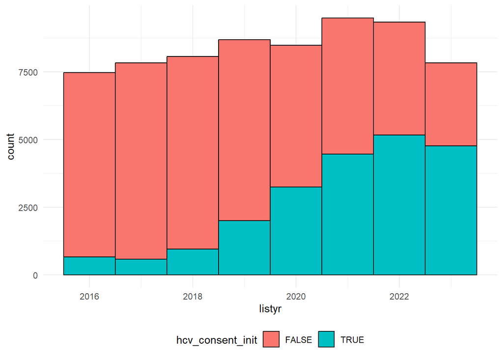

```r
histo_basic
```

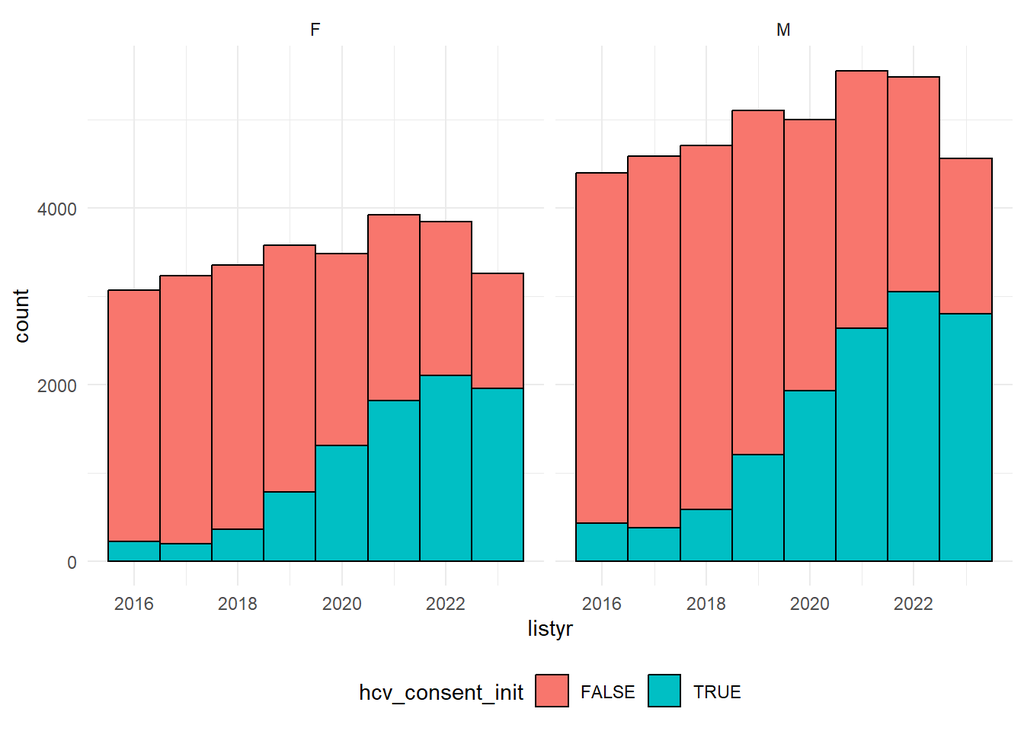

```r
histo_bysex
```

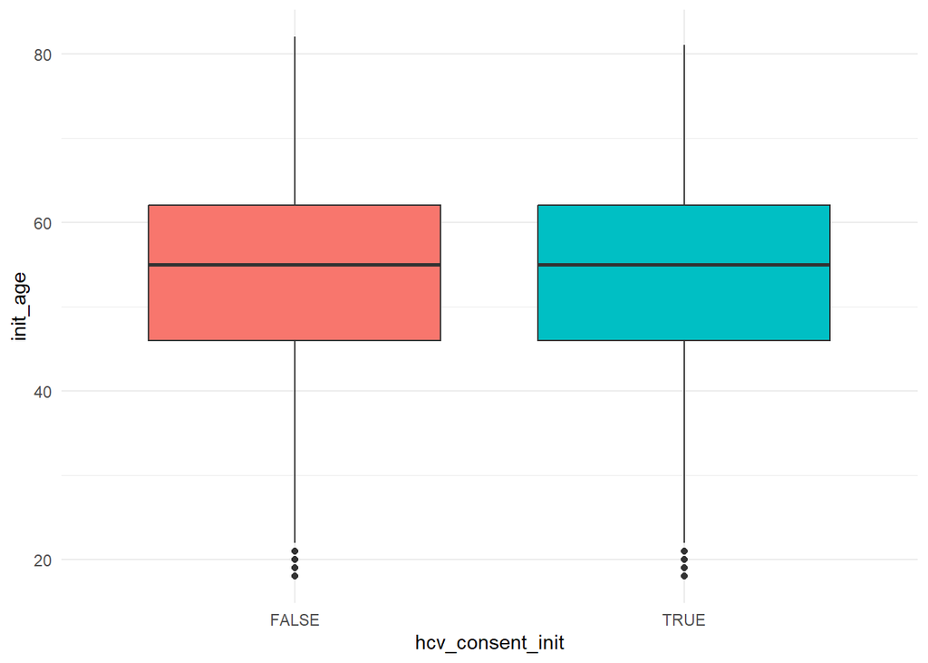

```r
box_byage
```

### 4.3 Logistic Regression - Factors influencing Consent

```r
hcv_log_res
```

```
# A tibble: 24 × 7
   term             estimate std.error statistic   p.value conf.low conf.high
   <chr>               <dbl>     <dbl>     <dbl>     <dbl>    <dbl>     <dbl>
 1 (Intercept)         0.359    0.0433    -23.7  5.38e-124    0.330     0.390
 2 sex.L               1.02     0.0125      1.38 1.68e-  1    0.993     1.04
 3 race_ethBlack       1.06     0.0358      1.55 1.20e-  1    0.985     1.13
 4 race_ethHispanic    0.857    0.0247     -6.24 4.34e- 10    0.816     0.899
 5 race_ethAsian       0.834    0.0545     -3.33 8.69e-  4    0.749     0.927
 6 race_ethOther       1.25     0.0619      3.55 3.84e-  4    1.10      1.41
 7 new_dxAutoimmune    0.576    0.0395    -14.0  2.51e- 44    0.533     0.623
 8 new_dxMASLD         0.641    0.0344    -12.9  2.77e- 38    0.599     0.686
 9 new_dxALD           0.740    0.0335     -9.01 2.02e- 19    0.693     0.790
10 new_dxMetALD        0.694    0.0363    -10.1  7.08e- 24    0.646     0.745
# ℹ 14 more rows
```

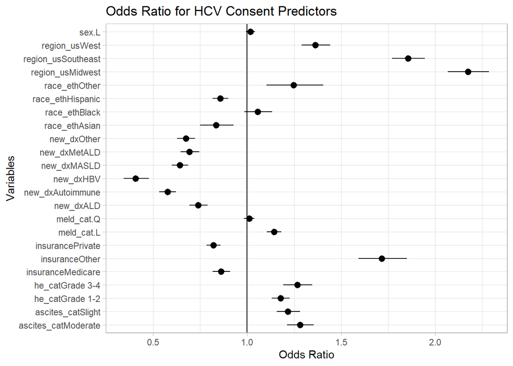

```r
hcv_log_res |>
  filter(!term == "(Intercept)") |>
  ggplot(aes(y = term, x = estimate,
                 xmin = conf.low, xmax = conf.high)) +
  geom_pointrange() +
  xlab("Odds Ratio") +
  ylab("Variables") +
  geom_vline(xintercept = 1) +
  ggtitle("Odds Ratio for HCV Consent Predictors") +
  theme_light()
```

### 4.4 Survival Analysis - Time to Transplant by HCV NAT+ Consent Status

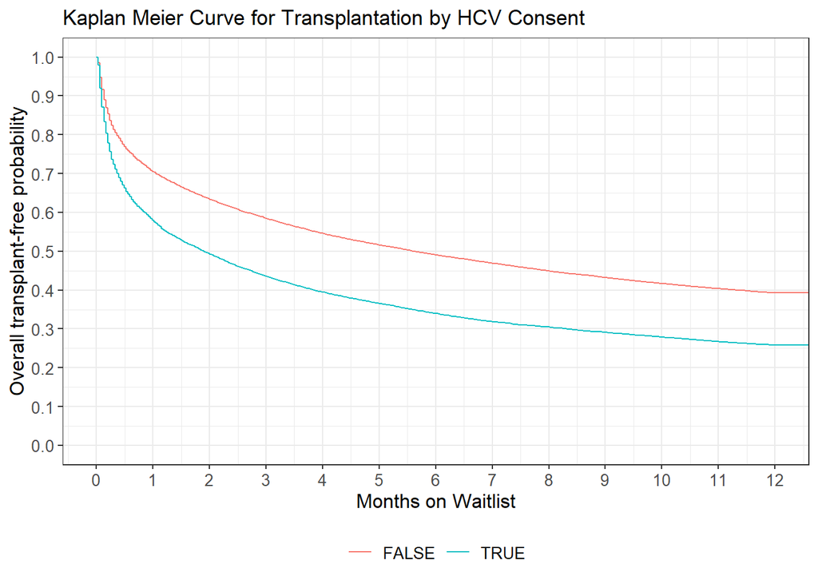

```r
hcv_kmcurve
```

```r
hcv_cox_res
```

```
# A tibble: 22 × 7
   term                estimate std.error statistic   p.value conf.low conf.high
   <chr>                  <dbl>     <dbl>     <dbl>     <dbl>    <dbl>     <dbl>
 1 hcv_consent_initTR…    1.47   0.0107       35.8  3.31e-281    1.44      1.50
 2 init_age               0.998  0.000461     -3.50 4.62e-  4    0.997     0.999
 3 sex.L                  1.09   0.00753      11.7  8.51e- 32    1.08      1.11
 4 race_ethBlack          1.05   0.0212        2.37 1.77e-  2    1.01      1.10
 5 race_ethHispanic       0.876  0.0149       -8.84 9.72e- 19    0.851     0.902
 6 race_ethAsian          0.966  0.0313       -1.12 2.63e-  1    0.908     1.03
 7 race_ethOther          0.792  0.0396       -5.90 3.69e-  9    0.733     0.856
 8 new_dxAutoimmune       1.17   0.0250        6.38 1.72e- 10    1.12      1.23
 9 new_dxMASLD            1.14   0.0224        5.84 5.07e-  9    1.09      1.19
10 new_dxALD              1.03   0.0220        1.24 2.16e-  1    0.984     1.07
# ℹ 12 more rows
```

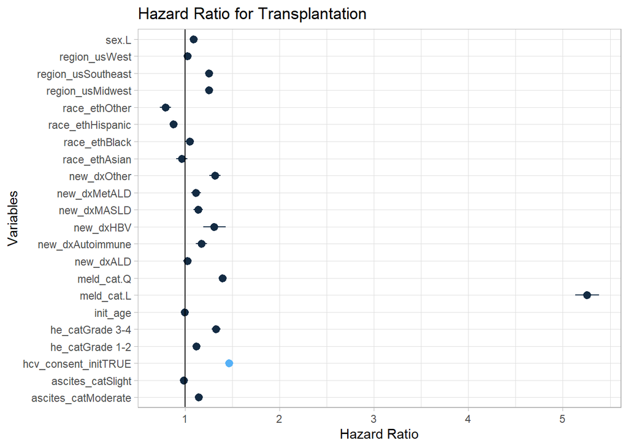

```r
hcv_cox_res |>
  filter(!term == "(Intercept)") |>
  mutate(categ = case_when(term == "hcv_consent_initTRUE" ~ 1, .default = 0)) |>
  ggplot(aes(y = term, x = estimate,
                 xmin = conf.low, xmax = conf.high, color = categ)) +
  geom_pointrange() +
  xlab("Hazard Ratio") +
  ylab("Variables") +
  geom_vline(xintercept = 1) +
  ggtitle("Hazard Ratio for Transplantation") +
  guides(color = "none") +
  theme_light()
```

## 5 Conclusion

This project analyzed the comprehensive UNOS Liver Transplant database to explore the determinants of agreeing to receive an HCV NAT+ livers when on the waitlist for liver transplantation, as well as the impact of consenting on the time to transplantation. These results clearly show that there is a lot of variability in the patients consenting to receive HCV NAT+ organs, especially by etiology of liver disease, severity of liver disease, and by region of the transplant center. Furthermore, there is definitive evidence here that those who consent to an HCV NAT+ organ have a statistically significant higher rate of transplantation in the first 12 months of listing.

These results will form the basis of more in-depth survival analysis exploring the impact on waitlist mortality as well as evaluating these outcomes with competing risks models.